# Background and Objective

# Cluster Profiling

```python
HCmodel = AgglomerativeClustering(n_clusters=3, affinity="euclidean", linkage="average")
HCmodel.fit(subset_scaled_df)
```

```
AgglomerativeClustering(linkage='average', n_clusters=3)
```

```python
subset_scaled_df["HC_Clusters"] = HCmodel.labels_
cred["HC_Clusters"] = HCmodel.labels_
```

```python
cluster_profile = cred.groupby("HC_Clusters").mean()
```

```python
cluster_profile["count_in_each_segments"] = (
    cred.groupby("HC_Clusters")["Avg_Credit_Limit"].count().values
)
```

```python
# lets display cluster profile
cluster_profile.style.highlight_max(color="lightgreen", axis=0)
```

| HC_Clusters | Avg_Credit_Limit | Total_Credit_Cards | Total_visits_bank | Total_visits_online | Total_calls_made | K_means_segments | count_in_each_segments |
| --- | --- | --- | --- | --- | --- | --- | --- |
| 0 | 33713.178295 | 5.511628 | 3.485788 | 0.984496 | 2.005168 | 0.002584 | 387 |
| 1 | 141040.000000 | 8.740000 | 0.600000 | 10.900000 | 1.080000 | 2.000000 | 50 |
| 2 | 12197.309417 | 2.403587 | 0.928251 | 3.560538 | 6.883408 | 1.000000 | 223 |

- Customer Segment 0 has the avg. credit limit 33713, total credit cards around 6 and total visits around 3 times. This customer group less willing to visit online. They prefer more visit physically and they are the biggest number of customer.
- Customer segement 2 avg. crdeit limit is 12197, and they hold 2.4 credit cards and they prefer more to call over telephone and they are the second biggest customer segement
- Cusotmer segment 1 is the smallest group, they are more affluent customer with around 9 credit cards and they make a lot of online visit and very relucatanct to go physically and make call over telephone

```python
# let's see the customer key in each cluster
for cl in cred["HC_Clusters"].unique():
    print(
        "The",
        cred[cred["HC_Clusters"] == cl]["Customer Key"].nunique(),
        "customer in cluster",
        cl,
        "are:",
    )
    print(cred[cred["HC_Clusters"] == cl]["Customer Key"].unique())
    print("-" * 100, "\n")
```

[output not shown]

[output cut: 27 more lines]

```
 '98969' '77143' '38205' '53851' '52783' '63405' '48510' '97463' '18145'
 '14398' '98288' '69704' '29058' '15546' '16715' '87350' '13215' '20593'
 '56624' '33317' '99596' '72430' '16676' '40486' '90958' '67212' '44226'
 '94251' '61776' '55275' '18609' '54477' '12122' '28208' '68003' '79632'
 '73811' '72892' '51773' '96163' '61234' '55849' '56156']
----------------------------------------------------------------------------------------------------

The 50 customer in cluster 1 are:
['47437' '48370' '94391' '50598' '40019' '77910' '89832' '98216' '54495'
 '47650' '32107' '84192' '53916' '32584' '97285' '20337' '15585' '20620'
 '75009' '76203' '33837' '14916' '97935' '16180' '49493' '70974' '40217'
 '88442' '17538' '90839' '99843' '27212' '91575' '60190' '18519' '48762'
 '58392' '79953' '13315' '30570' '78996' '78404' '28525' '51826' '65750'
 '51108' '60732' '53834' '80655' '80150']
----------------------------------------------------------------------------------------------------
```

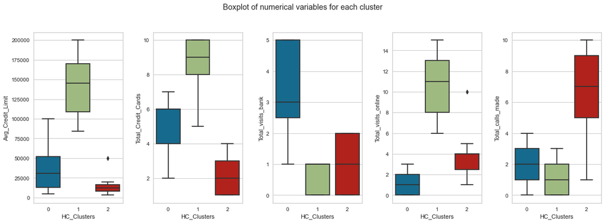

```python
fig, axes = plt.subplots(1, 5, figsize=(16, 6))
fig.suptitle("Boxplot of numerical variables for each cluster")
counter = 0
for ii in range(5):
    sns.boxplot(ax=axes[ii], y=cred[num_col[counter]], x=cred["HC_Clusters"])
    counter = counter + 1

fig.tight_layout(pad=2.0)
```

- With avg_cred_limit cluster 0 and 1 are very distnguished, whereas 0 and 2 little bit overlaping wtih one another
- In terms of Total_cred_cards also clusters are distingushed from one another
- However by total visits bank cluster 1 and 2 are overlaping with one another largely, the same also apply for 0 and 1 in Total calls made
- By total visits online, segements are very distinguished from one another
- Credit limit, total credit cards and in generall the type of visits of customer can be important indicators to segment customers and apply marketing and other strategies better. In case of interaction pattern, customer can be divided into two groups, online vs physical visits and call

# K-means vs Hierarchical Clustering

- In case numbe of clustes, both method producing the same number of clusters
- However, K means is presenting more clearer visibility than the Hierarchial clustering to choose the number of clusters and cluster profiles
- That also indicates, as the number of sample size in this case small, Hierarchical clustering is manageble. HOwever, in case of very large sample size, it would create more complexity
- Also in terms of time, hierarchical clustering more time consuming, that also indicates, it will be more expensive than k means clustering and if the data is large, then it will be more complex and expensive

# Insights and Recommendations

- Both clustering methods has produced almost similar kind of insights with kluster number = 3
- Only one customer has moved to another segment, if we compare clustering profile from two methods
- The biggest customer segment has moderate amount of credit limit around 30000 and around 5.5 credit cards and they prefer more physical visit than online and call.
- the second major group with around 12000 credit limit(lowest in term of credit limit and credit card amount), they prefer more calling over phone than online and physical visit
- The smallest group of customer, 50 in both methods, has the highest amount of credit and highest number of credit card and they are more prone to visit online than physical and telephone contact
- Bank should treat the customer and develop their marekting strategy according to the choice by their interaction preferances.
- The smallest group of customer is the most affluent, have more number of credit cards and also modern in terms of their interaction choice. Bank might more focus on them as from future perspective. They might more focus to attract this kind of customers and retain them
- The biggest customer segment is also have potential, as they are also moderate in terms of credit limit and holding credit card. However they more prefer physical visit. Therefore Bank should also improve their physcial facilities, decoration, number of branches, quality of service and employee, better understanding of service by the customer care employess etc.
- the second largest group with lowest amount of credit amount, lowest number of credit cards, prefer more communications with phone call. For them Bank should focus on more on improvement in call center, less waiting time.